# Análise de Regressão

computacional

Author

Affiliation

[Prof. Dr. Juliano Bortolini](http://www.julianobortolini.com.br)

Universidade Federal de Mato Grosso

*Bacharelado em Estatística - UFMT*

# Modelo de Regressão Linear Simples

## Experimento

O artigo **“Ecofriendly Dyeing of Silk with Extract of Yerba Mate”** (Textile Res. J. 2017: 829–837) descreve um experimento para estudar os efeitos da concentração de corante (mg/L), da temperatura (°C) e do pH na adsorção de corante (mg de corante por grama de tecido). Adsorção de corante é um indicador de cor.

$$Y = \beta_0 + \beta_1 X + \varepsilon$$

- $Y$: adsorção
- $X$: concentração
- $\varepsilon \sim N(0, \sigma^2)$

```r
dados <- data.frame(
  concentracao = c(10, 20, 20, 20, 10, 20, 10, 20, 15, 15),
  adsorcao = c(250, 520, 387, 593, 157, 377, 225, 451, 382, 373)
)
dados
```

```
   concentracao adsorcao
1            10      250
2            20      520
3            20      387
4            20      593
5            10      157
6            20      377
7            10      225
8            20      451
9            15      382
10           15      373
```

## Estatísticas descritivas

```r
summary(dados)
```

```
  concentracao      adsorcao
 Min.   :10.00   Min.   :157.0
 1st Qu.:11.25   1st Qu.:280.8
 Median :17.50   Median :379.5
 Mean   :16.00   Mean   :371.5
 3rd Qu.:20.00   3rd Qu.:435.0
 Max.   :20.00   Max.   :593.0
```

```r
sd(dados$concentracao)
```

```
[1] 4.594683
```

```r
sd(dados$adsorcao)
```

```
[1] 133.3552
```

## Correlação entre as variáveis

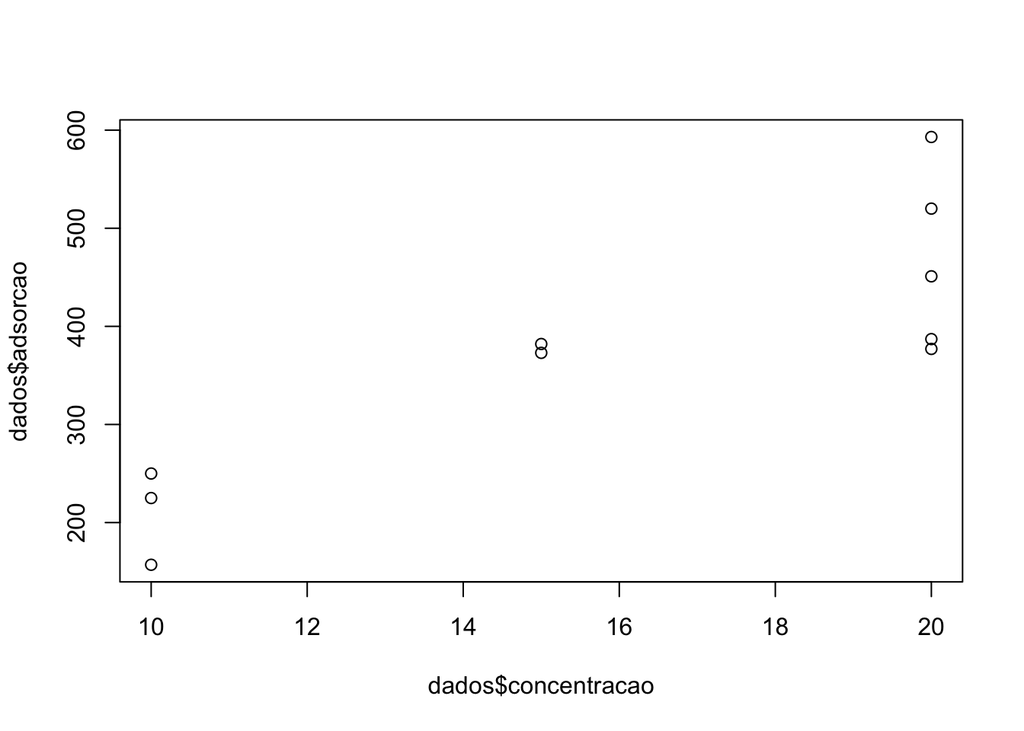

```r
plot(dados$concentracao, dados$adsorcao)
```

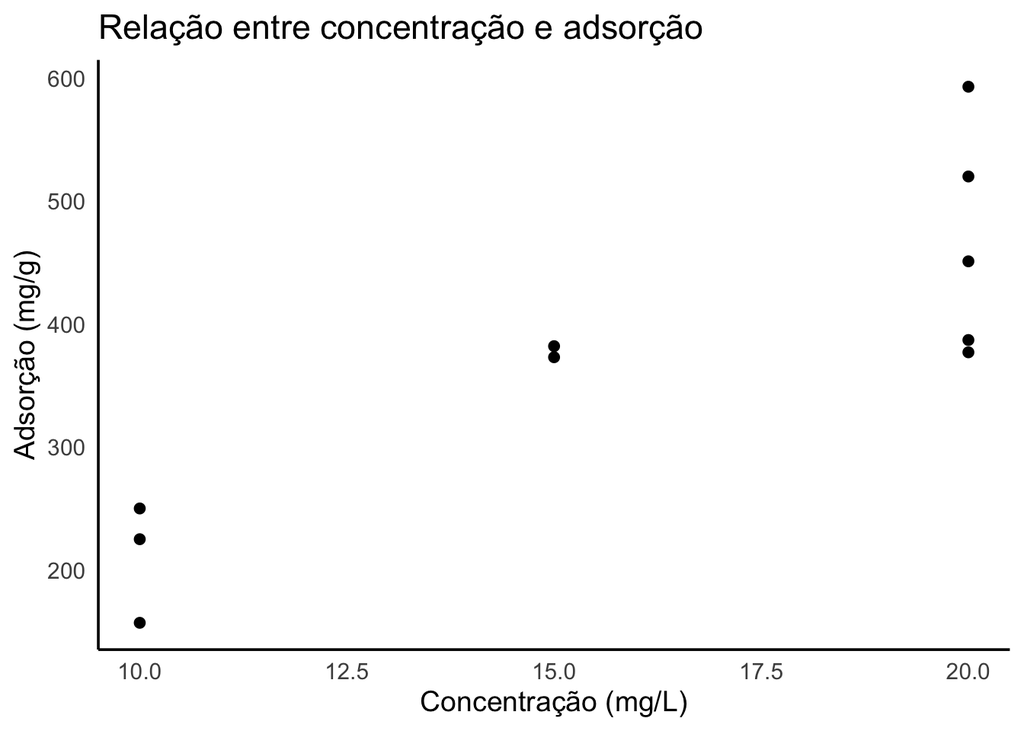

```r
ggplot(dados, aes(x = concentracao, y = adsorcao)) +
  geom_point() +
  labs(
    title = "Relação entre concentração e adsorção",
    x = "Concentração (mg/L)",
    y = "Adsorção (mg/g)"
  )
```

```r
cor(dados$concentracao, dados$adsorcao)
```

```
[1] 0.8640818
```

## Teste de hipóteses:

$H_0: rho = 0$

```r
cor.test(dados$concentracao, dados$adsorcao)
```

```
    Pearson's product-moment correlation

data:  dados$concentracao and dados$adsorcao
t = 4.8554, df = 8, p-value = 0.001263
alternative hypothesis: true correlation is not equal to 0
95 percent confidence interval:
 0.5142117 0.9673971
sample estimates:
      cor
0.8640818
```

- Observe o IC para $\rho$.

## Ajuste do modelo

```r
modelo <- lm(adsorcao ~ concentracao, data = dados)
modelo
```

```
Call:
lm(formula = adsorcao ~ concentracao, data = dados)

Coefficients:
 (Intercept)  concentracao
      -29.76         25.08
```

Logo, o modelo é dado por:

$$Y = -29.76 + 25.08 \text{ concentração}$$

```r
anova(modelo)
```

```
Analysis of Variance Table

Response: adsorcao
             Df Sum Sq Mean Sq F value   Pr(>F)
concentracao  1 119501  119501  23.575 0.001263 **
Residuals     8  40551    5069
---
Signif. codes:  0 '***' 0.001 '**' 0.01 '*' 0.05 '.' 0.1 ' ' 1
```

Estimativas, erros-padrões, estatísticas $t$, valores $p$, $\sigma$, $R^2$, $R^2_{aj}$, $F_c$ para regressão (e valor $p$):

```r
summary(modelo)
```

```
Call:
lm(formula = adsorcao ~ concentracao, data = dados)

Residuals:
   Min     1Q Median     3Q    Max
-94.82 -53.22  15.28  33.93 121.18

Coefficients:
             Estimate Std. Error t value Pr(>|t|)
(Intercept)   -29.763     85.654  -0.347  0.73719
concentracao   25.079      5.165   4.855  0.00126 **
---
Signif. codes:  0 '***' 0.001 '**' 0.01 '*' 0.05 '.' 0.1 ' ' 1

Residual standard error: 71.2 on 8 degrees of freedom
Multiple R-squared:  0.7466,    Adjusted R-squared:  0.715
F-statistic: 23.58 on 1 and 8 DF,  p-value: 0.001263
```

Testes de hipóteses:

$$H_0: \beta_0 = 0 \quad vs \quad H_1: \beta_0 \neq 0$$
$$H_0: \beta_1 = 0 \quad vs \quad H_1: \beta_1 \neq 0$$
Para o teste $t$ dos coeficientes, comparamos os valores $t_c$ com o valor $t_{tab} = t_{\alpha/2, gl(erro)}$

```r
qt(0.05/2, df = 8, lower.tail = FALSE) # t tabulado
```

```
[1] 2.306004
```

Para o teste de hipóteses, $i = 0$ ou $1$:
$$H_0: \beta_i = \beta_{i,0} \quad vs \quad H_1: \beta_i \neq \beta_{i,0}$$
onde $\beta_{i,0}$ é o valor hipotetizado para o parâmetro (geralmente 0).

A estatística de teste é dada por:
$$t_c = \frac{\hat{\beta}_i - \beta_{i,0}}{se(\hat{\beta}_i)}$$

Para o seguinte exemplo:
$$H_0: \beta_1 = 25 \quad vs \quad H_1: \beta_1 \neq 25$$

A estatística de teste é:
$$t_c = \frac{\hat{\beta}_1 - 25}{se(\hat{\beta}_1)}$$

```r
t_calc <- (25.079 - 25)/5.165
t_calc
```

```
[1] 0.01529526
```

```r
t_tab <- qt(0.05/2, df = 8, lower.tail = FALSE) # t tabulado
t_tab
```

```
[1] 2.306004
```

```r
t_calc > t_tab
```

```
[1] FALSE
```

```r
# portanto, não rejeitamos H_0!
```

Conclusões: 1. $\beta_0 = 0$: Não rejeita $H_0$ (p = 0.737) 2. $\beta_1 = 0$: Rejeita $H_0$ (p = 0.00126)

## Coeficientes (betas estimados)

```r
coef(modelo) # coeficientes
```

```
 (Intercept) concentracao
   -29.76316     25.07895
```

```r
confint(modelo) # IC para os coef.
```

```
                  2.5 %    97.5 %
(Intercept)  -227.28135 167.75504
concentracao   13.16815  36.98974
```

- $\hat{\beta}_0$: adsorção média quando a concentração é zero
- $\hat{\beta}_1$: variação média da adsorção para cada unidade de aumento na concentração

## Gráfico com a reta de regressão

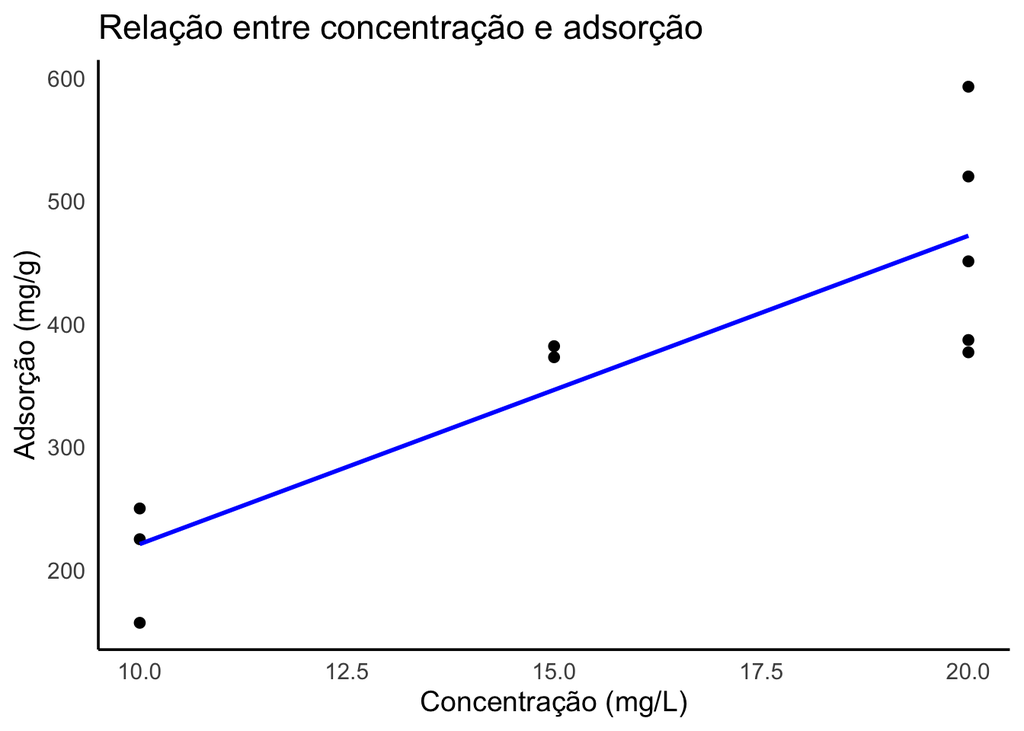

```r
dados$ajustado <- fitted(modelo)

ggplot(dados, aes(x = concentracao, y = adsorcao)) +
  geom_point() +
  geom_line(aes(y = ajustado), color = "blue", linewidth = 1) +
  labs(
    title = "Relação entre concentração e adsorção",
    x = "Concentração (mg/L)",
    y = "Adsorção (mg/g)"
  )
```

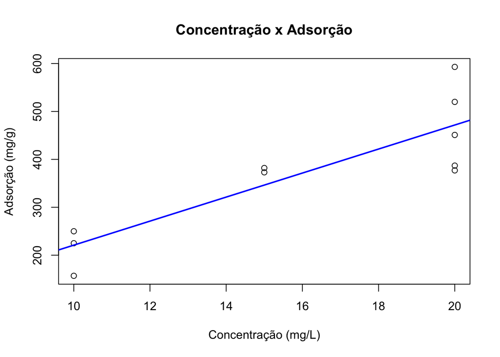

```r
plot(dados$concentracao, dados$adsorcao,
     main = "Concentração x Adsorção",
     xlab = "Concentração (mg/L)",
     ylab = "Adsorção (mg/g)")
abline(modelo, col = "blue", lwd = 2)
```

## SQ e QM dos resíduos:

```r
residuos <- residuals(modelo)
SQRes <- sum(residuos^2)
SQRes
```

```
[1] 40551.32
```

```r
GL_Res <- length(dados$adsorcao) - length(coef(modelo))
GL_Res
```

```
[1] 8
```

```r
QMRes <- SQRes / GL_Res
QMRes
```

```
[1] 5068.914
```

```r
sqrt(QMRes)
```

```
[1] 71.19631
```

## IC para resposta média

```r
preditos <- predict(modelo, interval = "confidence")
head(preditos)
```

```
       fit      lwr      upr
1 221.0263 132.6935 309.3591
2 471.8158 401.3506 542.2810
3 471.8158 401.3506 542.2810
4 471.8158 401.3506 542.2810
5 221.0263 132.6935 309.3591
6 471.8158 401.3506 542.2810
```

```r
colnames(preditos) <- c("adsorcao_estimada", "lim_inf", "lim_sup")
head(preditos)
```

```
  adsorcao_estimada  lim_inf  lim_sup
1          221.0263 132.6935 309.3591
2          471.8158 401.3506 542.2810
3          471.8158 401.3506 542.2810
4          471.8158 401.3506 542.2810
5          221.0263 132.6935 309.3591
6          471.8158 401.3506 542.2810
```

```r
dados <- cbind(dados, preditos)
dados
```

```
   concentracao adsorcao ajustado adsorcao_estimada  lim_inf  lim_sup
1            10      250 221.0263          221.0263 132.6935 309.3591
2            20      520 471.8158          471.8158 401.3506 542.2810
3            20      387 471.8158          471.8158 401.3506 542.2810
4            20      593 471.8158          471.8158 401.3506 542.2810
5            10      157 221.0263          221.0263 132.6935 309.3591
6            20      377 471.8158          471.8158 401.3506 542.2810
7            10      225 221.0263          221.0263 132.6935 309.3591
8            20      451 471.8158          471.8158 401.3506 542.2810
9            15      382 346.4211          346.4211 293.1544 399.6877
10           15      373 346.4211          346.4211 293.1544 399.6877
```

**Ordernar o banco de dados pela concentração:**

```r
dados <- dados[order(dados$concentracao),]
dados
```

```
   concentracao adsorcao ajustado adsorcao_estimada  lim_inf  lim_sup
1            10      250 221.0263          221.0263 132.6935 309.3591
5            10      157 221.0263          221.0263 132.6935 309.3591
7            10      225 221.0263          221.0263 132.6935 309.3591
9            15      382 346.4211          346.4211 293.1544 399.6877
10           15      373 346.4211          346.4211 293.1544 399.6877
2            20      520 471.8158          471.8158 401.3506 542.2810
3            20      387 471.8158          471.8158 401.3506 542.2810
4            20      593 471.8158          471.8158 401.3506 542.2810
6            20      377 471.8158          471.8158 401.3506 542.2810
8            20      451 471.8158          471.8158 401.3506 542.2810
```

## Gráfico com IC para a resposta média

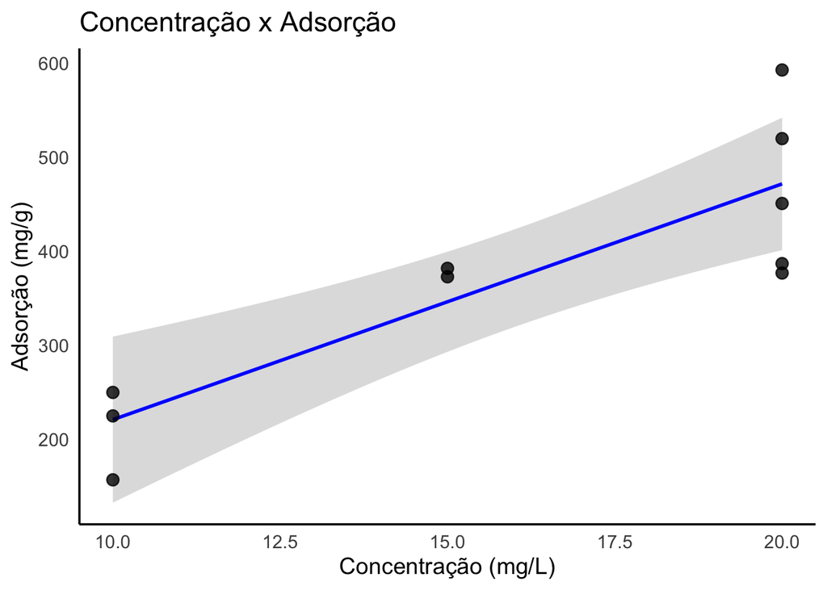

```r
grid <- data.frame(concentracao = seq(min(dados$concentracao),
                                      max(dados$concentracao),
                                      length.out = 200))
pred  <- as.data.frame(predict(modelo, newdata = grid, interval = "confidence"))
pred  <- cbind(grid, pred)


ggplot() +
  geom_ribbon(data = pred,
              aes(x = concentracao, ymin = lwr, ymax = upr),
              alpha = 0.18) +
  geom_line(data = pred,
            aes(x = concentracao, y = fit),
            color = "blue",
            linewidth = 1) +
  geom_point(data = dados,
             aes(x = concentracao, y = adsorcao),
             size = 3, alpha = 0.8) +
  labs(
    title = "Concentração x Adsorção",
    x = "Concentração (mg/L)",
    y = "Adsorção (mg/g)"
  )
```

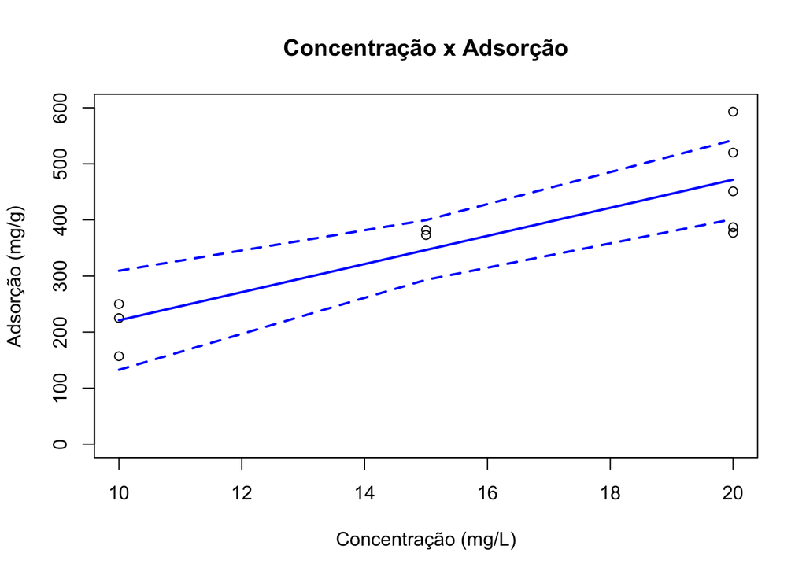

```r
plot(dados$concentracao, dados$adsorcao,
     main = "Concentração x Adsorção",
     xlab = "Concentração (mg/L)",
     ylab = "Adsorção (mg/g)",
     xlim = c(10,20),
     ylim = c(0, 600))

# valores estimados
lines(dados$concentracao, dados$adsorcao_estimada,
      col = "blue", lty = 1, lwd = 2)
# IC
lines(dados$concentracao, dados$lim_inf,
      col = "blue", lty = 2, lwd = 2)
lines(dados$concentracao, dados$lim_sup,
      col = "blue", lty = 2, lwd = 2)
```

## IC para novas observações (IP)

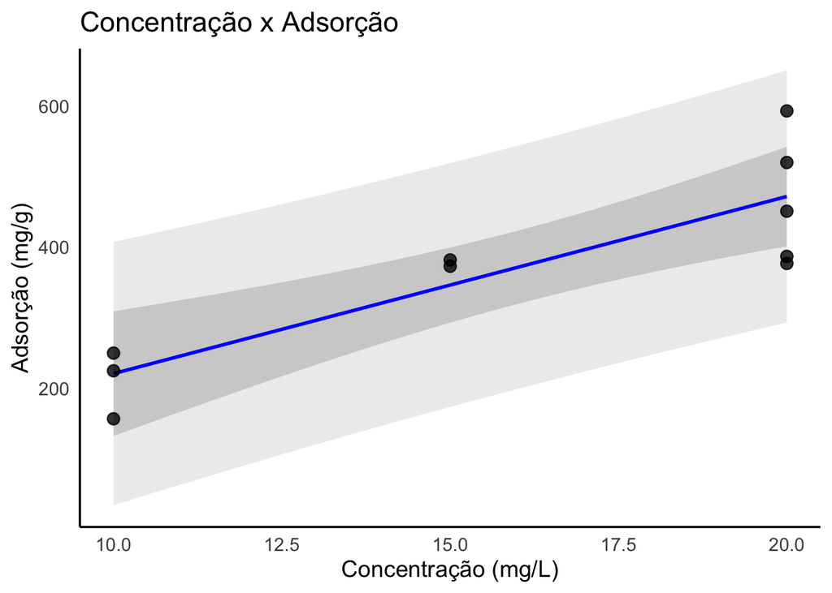

```r
pred_new  <- as.data.frame(predict(modelo, newdata = grid, interval = "prediction"))
colnames(pred_new) <- c("fit", "lwr_new", "upr_new")
pred  <- cbind(pred, pred_new[,2:3])


ggplot() +
  geom_ribbon(data = pred,
              aes(x = concentracao, ymin = lwr, ymax = upr),
              alpha = 0.18) +
  geom_ribbon(data = pred,
              aes(x = concentracao, ymin = lwr_new, ymax = upr_new),
              alpha = 0.1) +
  geom_line(data = pred,
            aes(x = concentracao, y = fit),
            color = "blue",
            linewidth = 1) +
  geom_point(data = dados,
             aes(x = concentracao, y = adsorcao),
             size = 3, alpha = 0.8) +
  labs(
    title = "Concentração x Adsorção",
    x = "Concentração (mg/L)",
    y = "Adsorção (mg/g)"
  )
```

```r
new_data <- data.frame(concentracao = seq(0,30, by = 1))
preditos_new <- predict(modelo, newdata = new_data,
                        interval = "prediction")
preditos_new <- cbind(new_data, preditos_new)
head(preditos_new)
```

```
  concentracao        fit       lwr      upr
1            0 -29.763158 -286.6059 227.0795
2            1  -4.684211 -252.8178 243.4494
3            2  20.394737 -219.3054 260.0949
4            3  45.473684 -186.0986 277.0460
5            4  70.552632 -153.2309 294.3362
6            5  95.631579 -120.7388 312.0019
```

## Gráfico com IP para novas observações

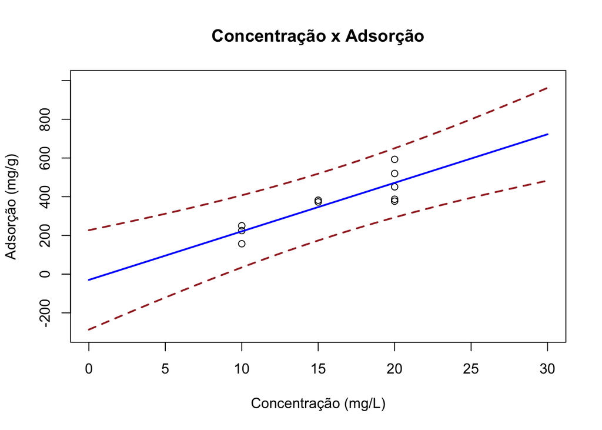

```r
# dispersão
plot(dados$concentracao, dados$adsorcao,
     main = "Concentração x Adsorção",
     xlab = "Concentração (mg/L)",
     ylab = "Adsorção (mg/g)",
     xlim = c(0,30),
     ylim = c(-300, 1000))
# valores estimados
lines(preditos_new$concentracao, preditos_new$fit,
      col = "blue", lty = 1, lwd = 2)
# IP
lines(preditos_new$concentracao, preditos_new$lwr,
      col = "brown", lty = 2, lwd = 2)
lines(preditos_new$concentracao, preditos_new$upr,
      col = "brown", lty = 2, lwd = 2)
```

## Gráfico com IC e IP

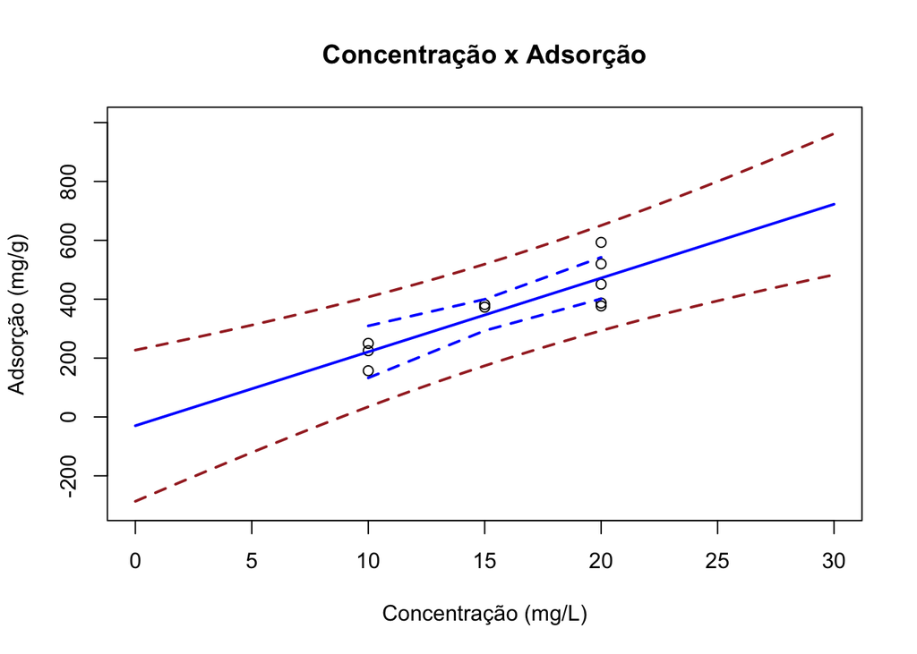

```r
# dispersão
plot(dados$concentracao, dados$adsorcao,
     main = "Concentração x Adsorção",
     xlab = "Concentração (mg/L)",
     ylab = "Adsorção (mg/g)",
     xlim = c(0,30),
     ylim = c(-300, 1000))

# valores estimados
lines(preditos_new$concentracao, preditos_new$fit,
      col = "blue", lty = 1, lwd = 2)

# IC
lines(dados$concentracao, dados$lim_inf,
      col = "blue", lty = 2, lwd = 2)
lines(dados$concentracao, dados$lim_sup,
      col = "blue", lty = 2, lwd = 2)

# IP
lines(preditos_new$concentracao, preditos_new$lwr,
      col = "brown", lty = 2, lwd = 2)
lines(preditos_new$concentracao, preditos_new$upr,
      col = "brown", lty = 2, lwd = 2)
```

## Regressão pela origem

```r
modelo2 <- lm(adsorcao ~ -1 + concentracao, data = dados)
modelo2
```

```
Call:
lm(formula = adsorcao ~ -1 + concentracao, data = dados)

Coefficients:
concentracao
       23.35
```

```r
anova(modelo2)
```

```
Analysis of Variance Table

Response: adsorcao
             Df  Sum Sq Mean Sq F value    Pr(>F)
concentracao  1 1499012 1499012  327.75 2.182e-08 ***
Residuals     9   41163    4574
---
Signif. codes:  0 '***' 0.001 '**' 0.01 '*' 0.05 '.' 0.1 ' ' 1
```

```r
summary(modelo2)
```

```
Call:
lm(formula = adsorcao ~ -1 + concentracao, data = dados)

Residuals:
    Min      1Q  Median      3Q     Max
-89.945 -61.341   4.027  29.541 126.055

Coefficients:
             Estimate Std. Error t value Pr(>|t|)
concentracao    23.35       1.29    18.1 2.18e-08 ***
---
Signif. codes:  0 '***' 0.001 '**' 0.01 '*' 0.05 '.' 0.1 ' ' 1

Residual standard error: 67.63 on 9 degrees of freedom
Multiple R-squared:  0.9733,    Adjusted R-squared:  0.9703
F-statistic: 327.7 on 1 and 9 DF,  p-value: 2.182e-08
```

## Comparação entre modelo completo e modelo reduzido (sem intercepto)

```r
anova(modelo2, modelo)
```

```
Analysis of Variance Table

Model 1: adsorcao ~ -1 + concentracao
Model 2: adsorcao ~ concentracao
  Res.Df   RSS Df Sum of Sq      F Pr(>F)
1      9 41163
2      8 40551  1    612.04 0.1207 0.7372
```

Se não há diferença entre os modelos, qual deve ser escolhido?

## Comparação entre modelo completo e modelo reduzido (sem intercepto)

```r
anova(modelo2, modelo)
```

```
Analysis of Variance Table

Model 1: adsorcao ~ -1 + concentracao
Model 2: adsorcao ~ concentracao
  Res.Df   RSS Df Sum of Sq      F Pr(>F)
1      9 41163
2      8 40551  1    612.04 0.1207 0.7372
```

Se não há diferença entre os modelos, qual deve ser escolhido?

**O modelo mais simples: com menos parâmetros.**

## Comparação de R2 e R2ajustado

```r
summary(modelo)
```

```
Call:
lm(formula = adsorcao ~ concentracao, data = dados)

Residuals:
   Min     1Q Median     3Q    Max
-94.82 -53.22  15.28  33.93 121.18

Coefficients:
             Estimate Std. Error t value Pr(>|t|)
(Intercept)   -29.763     85.654  -0.347  0.73719
concentracao   25.079      5.165   4.855  0.00126 **
---
Signif. codes:  0 '***' 0.001 '**' 0.01 '*' 0.05 '.' 0.1 ' ' 1

Residual standard error: 71.2 on 8 degrees of freedom
Multiple R-squared:  0.7466,    Adjusted R-squared:  0.715
F-statistic: 23.58 on 1 and 8 DF,  p-value: 0.001263
```

```r
summary(modelo2)
```

```
Call:
lm(formula = adsorcao ~ -1 + concentracao, data = dados)

Residuals:
    Min      1Q  Median      3Q     Max
-89.945 -61.341   4.027  29.541 126.055

Coefficients:
             Estimate Std. Error t value Pr(>|t|)
concentracao    23.35       1.29    18.1 2.18e-08 ***
---
Signif. codes:  0 '***' 0.001 '**' 0.01 '*' 0.05 '.' 0.1 ' ' 1

Residual standard error: 67.63 on 9 degrees of freedom
Multiple R-squared:  0.9733,    Adjusted R-squared:  0.9703
F-statistic: 327.7 on 1 and 9 DF,  p-value: 2.182e-08
```

# Modelo de Regressão Linear Múltipla

Seja $Y$ a adsorção de corante, $X_1$ a concentração, $X_2$ a temperatura e $X_3$ o pH. O modelo de regressão linear múltipla, que relaciona a adsorção com as variáveis explicativas é dado por:
$$Y = \beta_0 + \beta_1 X_1 + \beta_2 X_2 + \beta_3 X_3 + \varepsilon,$$

em que, $\varepsilon \sim N(0, \sigma^2)$, $Y$ é a variável resposta (adsorção) e $X_1$, $X_2$ e $X_3$ são as variáveis explicativas (concentração, temperatura e pH, respectivamente).

```r
dados <- data.frame(
  conc = c(10, 20, 20, 20, 10, 20, 10, 20, 15, 15),
  temp = c(70, 70, 80, 90, 70, 70, 90, 90, 80, 80),
  ph = c(3.0, 3.0, 3.0, 3.0, 4.0, 4.0, 4.0, 4.0, 3.5, 3.5),
  adsorcao = c(250, 520, 387, 593, 157, 377, 225, 451, 382, 373)
)
dados
```

```
   conc temp  ph adsorcao
1    10   70 3.0      250
2    20   70 3.0      520
3    20   80 3.0      387
4    20   90 3.0      593
5    10   70 4.0      157
6    20   70 4.0      377
7    10   90 4.0      225
8    20   90 4.0      451
9    15   80 3.5      382
10   15   80 3.5      373
```

## Ajuste do modelo (regressão múltipla)

O modelo de regreão linear múltipla é estimado pela função `lm()` do R, que é uma função genérica para ajuste de modelos lineares. O modelo é ajustado pela função `lm()` usando a fórmula `adsorcao ~ conc + temp + ph`, que indica que a variável resposta é `adsorcao` e as variáveis explicativas são `conc`, `temp` e `ph`.

```r
# regressão múltipla
modelo3 <- lm(adsorcao ~ conc + temp + ph, data = dados)
modelo3
```

```
Call:
lm(formula = adsorcao ~ conc + temp + ph, data = dados)

Coefficients:
(Intercept)         conc         temp           ph
     53.759       21.548        3.657      -90.272
```

A análise de variância do modelo é realizada pela função `anova()`, que é uma função genérica para análise de variância de modelos ajustados. O modelo é passado como argumento para a função `anova()`, que retorna a tabela de análise de variância do modelo, incluindo as somas de quadrados, graus de liberdade, quadrados médios, estatística $F$ e valor $p$ para o teste de significância global do modelo.

```r
anova(modelo3)
```

```
Analysis of Variance Table

Response: adsorcao
          Df Sum Sq Mean Sq F value   Pr(>F)
conc       1 119501  119501 34.6477 0.001066 **
temp       1   5157    5157  1.4952 0.267261
ph         1  14700   14700  4.2621 0.084530 .
Residuals  6  20694    3449
---
Signif. codes:  0 '***' 0.001 '**' 0.01 '*' 0.05 '.' 0.1 ' ' 1
```

```r
coef(modelo3) # coeficientes
```

```
(Intercept)        conc        temp          ph
  53.758696   21.548478    3.657174  -90.271739
```

A função que calcula os intervalos de confiança para os coeficientes é a função `confint()`, que é uma função genérica para calcular intervalos de confiança para os parâmetros de um modelo ajustado. O modelo é passado como argumento para a função `confint()`, que retorna os intervalos de confiança para os coeficientes do modelo. O padrão do nível de confiança é 95%, mas pode ser alterado usando o argumento `level`.

```r
confint(modelo3) # IC para os coef.
```

```
                  2.5 %     97.5 %
(Intercept) -507.581522 615.098914
conc          10.518537  32.578419
temp          -1.988525   9.302873
ph          -197.265543  16.722065
```

Uma função que apresenta os coeficientes estimados, erros-padrões, estatísticas $t$ e valores $p$ é a função `summary()`, que é uma função genérica para sumarizar os resultados de um modelo ajustado. O modelo é sumarizado pela função `summary(modelo3)`, que apresenta as informações mencionadas.

```r
summary(modelo3)
```

```
Call:
lm(formula = adsorcao ~ conc + temp + ph, data = dados)

Residuals:
     Min       1Q   Median       3Q      Max
-119.487   -6.477   -2.215   26.141   50.085

Coefficients:
            Estimate Std. Error t value Pr(>|t|)
(Intercept)   53.759    229.408   0.234  0.82252
conc          21.548      4.508   4.780  0.00306 **
temp           3.657      2.307   1.585  0.16405
ph           -90.272     43.726  -2.064  0.08453 .
---
Signif. codes:  0 '***' 0.001 '**' 0.01 '*' 0.05 '.' 0.1 ' ' 1

Residual standard error: 58.73 on 6 degrees of freedom
Multiple R-squared:  0.8707,    Adjusted R-squared:  0.8061
F-statistic: 13.47 on 3 and 6 DF,  p-value: 0.004493
```

## IC para resposta média

Será apresentado a seguir como calcular os intervalos de confiança para a resposta média, ou seja, para a predição da adsorção de corante para cada combinação de concentração, temperatura e pH presentes no banco de dados. Para isso, é utilizada a função `predict()`, que é uma função genérica para fazer predições a partir de um modelo ajustado. O modelo é passado como argumento para a função `predict()`, juntamente com o argumento `interval = "confidence"`, que indica que os intervalos de confiança devem ser calculados para os valores médios da resposta. A função retorna uma matriz com as predições da resposta média, os limites inferior e superior dos intervalos de confiança para cada combinação de variáveis explicativas presentes no banco de dados.

```r
preditos_mod3 <- predict(modelo3, interval = "confidence")
head(preditos_mod3)
```

```
       fit      lwr      upr
1 254.4304 147.2270 361.6338
2 469.9152 380.2725 559.5579
3 506.4870 431.8766 581.0974
4 543.0587 445.7325 640.3849
5 164.1587  66.8325 261.4849
6 379.6435 266.7295 492.5575
```

```r
colnames(preditos_mod3) <- c("adsorcao_estimada", "lim_inf", "lim_sup")
head(preditos_mod3)
```

```
  adsorcao_estimada  lim_inf  lim_sup
1          254.4304 147.2270 361.6338
2          469.9152 380.2725 559.5579
3          506.4870 431.8766 581.0974
4          543.0587 445.7325 640.3849
5          164.1587  66.8325 261.4849
6          379.6435 266.7295 492.5575
```

```r
dados <- cbind(dados, preditos_mod3)
dados
```

```
   conc temp  ph adsorcao adsorcao_estimada  lim_inf  lim_sup
1    10   70 3.0      250          254.4304 147.2270 361.6338
2    20   70 3.0      520          469.9152 380.2725 559.5579
3    20   80 3.0      387          506.4870 431.8766 581.0974
4    20   90 3.0      593          543.0587 445.7325 640.3849
5    10   70 4.0      157          164.1587  66.8325 261.4849
6    20   70 4.0      377          379.6435 266.7295 492.5575
7    10   90 4.0      225          237.3022 129.4725 345.1319
8    20   90 4.0      451          452.7870 354.3144 551.2596
9    15   80 3.5      382          353.6087 306.2310 400.9863
10   15   80 3.5      373          353.6087 306.2310 400.9863
```

## IC para novas observações (IP)

Quando queremos calcular os intervalos de predição para novas observações, ou seja, para combinações de concentração, temperatura e pH que não estão presentes no banco de dados, utilizamos a função `predict()` com o argumento `interval = "prediction"`. A função retorna uma matriz com as predições da resposta para as novas observações, os limites inferior e superior dos intervalos de predição para cada combinação de variáveis explicativas presentes no banco de dados. Para isso, é necessário criar um novo banco de dados com as combinações de concentração, temperatura e pH para as quais se deseja calcular os intervalos de predição. A seguir, é apresentado um exemplo de como criar um novo banco de dados e calcular os intervalos de predição para essas novas observações.

```r
new_data <- data.frame(conc = c(12, 12 , 25, 25),
                       temp = c(50, 80, 50, 80),
                       ph = c(6.0, 6.0, 6.0, 6.0))
preditos_new_mod3 <- predict(modelo3, newdata = new_data,
                        interval = "prediction")
preditos_new_mod3 <- cbind(new_data, preditos_new_mod3)
preditos_new_mod3
```

```
  conc temp ph       fit          lwr      upr
1   12   50  6 -46.43130 -406.3418415 313.4792
2   12   80  6  63.28391 -235.1306176 361.6984
3   25   50  6 233.69891 -177.5734979 644.9713
4   25   80  6 343.41413   -0.8326895 687.6610
```

# Análise de resíduos

A análise de resíduos é uma etapa importante na avaliação do ajuste do modelo de regressão. Os resíduos são as diferenças entre os valores observados e os valores ajustados pelo modelo. A análise de resíduos envolve a verificação de suposições do modelo, como normalidade, homocedasticidade e independência dos resíduos, além da identificação de possíveis outliers ou pontos influentes.

Há diversos tipos de resíduos, como resíduos brutos, resíduos padronizados, resíduos studentizados, resíduos PRESS e resíduos R-Student. Cada tipo de resíduo tem suas próprias características e é utilizado para diferentes propósitos na análise de resíduos.

O resíduo bruto é a diferença simples entre o valor observado e o valor ajustado pelo modelo. Ou seja, $e_i = y_i - \hat{y}_i$, onde $y_i$ é o valor observado e $\hat{y}_i$ é o valor ajustado pelo modelo para a observação $i$.

O resíduo padronizado é o resíduo bruto dividido pelo desvio padrão dos resíduos, o que permite comparar os resíduos em diferentes escalas. Isso é dado por $d_i^* = \frac{e_i}{\hat{\sigma}}$, onde $\hat{\sigma}$ é a estimativa do desvio padrão dos resíduos. Em geral, o valor de $\sigma$ é estimado pelo modelo de regressão, e é dado por $\hat{\sigma} = \sqrt{QMRes}$, onde $QMRes$ é o quadrado médio dos resíduos.

Na definição do resíduo studentizado (internamente), considera-se variância do resíduo bruto e a matriz $H$. O resíduo studentizado é definido por $r_i = \frac{e_i}{\hat{\sigma} \sqrt{1 - h_{ii}}}$, onde $h_{ii}$ é o elemento da matriz $H$ correspondente à observação $i$. O resíduo studentizado é uma medida de quão grande é o resíduo em relação à variabilidade dos resíduos, levando em consideração a influência da observação $i$ no ajuste do modelo. A justificativa para esse resíduo é que $Var(e) = Var(Y - \hat{Y}) = Var((I - H)Y) = (I - H)\sigma^2$, consequentemente, $Var(e_i) = (1 - h_{ii})\sigma^2$, sendo $h_{ii}$ o elemento da diagonal da matriz $H$, que representa a influência da observação $i$ no ajuste do modelo. Assim, o resíduo studentizado leva em consideração a variabilidade dos resíduos e a influência da observação $i$ no ajuste do modelo, o que o torna uma medida mais robusta para identificar outliers e pontos influentes.

O resíduo PRESS é o resíduo studentizado calculado para cada observação, considerando a exclusão dessa observação do ajuste do modelo. Matematicamente, tem-se que $e_(i) = y_i - \hat{y}_{(i)}$, onde $\hat{y}_{(i)}$ é o valor ajustado pelo modelo de regressão quando as observações do indivíduo $i$ são excluídas do ajuste. O resíduo PRESS é utilizado para avaliar a capacidade de predição do modelo, pois considera a influência de cada observação no ajuste do modelo e a variabilidade dos resíduos.

O resíduo R-Student é o resíduo studentizado calculado para cada observação, considerando a exclusão dessa observação do ajuste do modelo e a variabilidade dos resíduos. Ou seja, $t_i = \frac{e_i}{\hat{\sigma}_{(i)} \sqrt{1 - h_{ii}}}$, onde $\hat{\sigma}_{(i)}$ é a estimativa do desvio padrão dos resíduos quando as observações do indivíduo $i$ são excluídas do ajuste do modelo. O resíduo R-Student é utilizado para identificar outliers e pontos influentes, pois leva em consideração a influência das observações do indivíduo $i$ no ajuste do modelo e a variabilidade dos resíduos, mesmo quando essa observação é excluída do ajuste.

Example 3.1 The Delivery Time Data (Montgomery, Peck e Vining, 2021, p. 76)

> A soft drink bottler is analyzing the vending machine service routes in his distribution system. He is interested in predicting the amount of time required by the route driver to service the vending machines in an outlet. This service activity includes stocking the machine with beverage products and minor maintenance or housekeeping. The industrial engineer responsible for the study has suggested that the two most important variables affecting the delivery time (y) are the number of cases of product stocked (x1) and the distance walked by the route driver (x2). The engineer has collected 25 observations on delivery time:

```r
ID <- c(1, 2, 3, 4, 5, 6, 7, 8, 9, 10,
        11, 12, 13, 14, 15, 16, 17, 18, 19, 20,
        21, 22, 23, 24, 25)

y <- c(16.68, 11.50, 12.03, 14.88, 13.75, 18.11, 8.00, 17.83, 79.24, 21.50,
       40.33, 21.00, 13.50, 19.75, 24.00, 29.00, 15.35, 19.00, 9.50, 35.10,
       17.90, 52.32, 18.75, 19.83, 10.75)

x1 <- c(7, 3, 3, 4, 6, 7, 2, 7, 30, 5,
        16, 10, 4, 6, 9, 10, 6, 7, 3, 17,
        10, 26, 9, 8, 4)

x2 <- c(560, 220, 340, 80, 150, 330, 110, 210, 1460, 605,
        688, 215, 255, 462, 448, 776, 200, 132, 36, 770,
        140, 810, 450, 635, 150)

dados <- data.frame(ID, y, x1, x2)
head(dados)
```

```
  ID     y x1  x2
1  1 16.68  7 560
2  2 11.50  3 220
3  3 12.03  3 340
4  4 14.88  4  80
5  5 13.75  6 150
6  6 18.11  7 330
```

```r
# descritiva dos dados
summary(dados)
```

```
       ID           y               x1              x2
 Min.   : 1   Min.   : 8.00   Min.   : 2.00   Min.   :  36.0
 1st Qu.: 7   1st Qu.:13.75   1st Qu.: 4.00   1st Qu.: 150.0
 Median :13   Median :18.11   Median : 7.00   Median : 330.0
 Mean   :13   Mean   :22.38   Mean   : 8.76   Mean   : 409.3
 3rd Qu.:19   3rd Qu.:21.50   3rd Qu.:10.00   3rd Qu.: 605.0
 Max.   :25   Max.   :79.24   Max.   :30.00   Max.   :1460.0
```

```r
# Ajuste do modelo linear múltipla
mod <- lm(y ~ x1 + x2, data = dados)

# estimativas dos parâmetros/coeficientes
summary(mod)
```

```
Call:
lm(formula = y ~ x1 + x2, data = dados)

Residuals:
    Min      1Q  Median      3Q     Max
-5.7880 -0.6629  0.4364  1.1566  7.4197

Coefficients:
            Estimate Std. Error t value Pr(>|t|)
(Intercept) 2.341231   1.096730   2.135 0.044170 *
x1          1.615907   0.170735   9.464 3.25e-09 ***
x2          0.014385   0.003613   3.981 0.000631 ***
---
Signif. codes:  0 '***' 0.001 '**' 0.01 '*' 0.05 '.' 0.1 ' ' 1

Residual standard error: 3.259 on 22 degrees of freedom
Multiple R-squared:  0.9596,    Adjusted R-squared:  0.9559
F-statistic: 261.2 on 2 and 22 DF,  p-value: 4.687e-16
```

```r
# valores preditos
y_hat <- predict(mod)
y_hat
```

```
        1         2         3         4         5         6         7         8
21.708084 10.353615 12.079794  9.955646 14.194398 18.399574  7.155376 16.673395
        9        10        11        12        13        14        15        16
71.820294 19.123587 38.092507 21.593041 12.472991 18.682464 23.328798 29.662928
       17        18        19        20        21        22        23        24
14.913640 15.551379  7.706807 40.887970 20.514179 56.006528 23.357568 24.402854
       25
10.962584
```

```r
dados <- cbind(dados, y_hat)
head(dados)
```

```
  ID     y x1  x2     y_hat
1  1 16.68  7 560 21.708084
2  2 11.50  3 220 10.353615
3  3 12.03  3 340 12.079794
4  4 14.88  4  80  9.955646
5  5 13.75  6 150 14.194398
6  6 18.11  7 330 18.399574
```

```r
# estimativa de sigma^2
summary(mod)
```

```
Call:
lm(formula = y ~ x1 + x2, data = dados)

Residuals:
    Min      1Q  Median      3Q     Max
-5.7880 -0.6629  0.4364  1.1566  7.4197

Coefficients:
            Estimate Std. Error t value Pr(>|t|)
(Intercept) 2.341231   1.096730   2.135 0.044170 *
x1          1.615907   0.170735   9.464 3.25e-09 ***
x2          0.014385   0.003613   3.981 0.000631 ***
---
Signif. codes:  0 '***' 0.001 '**' 0.01 '*' 0.05 '.' 0.1 ' ' 1

Residual standard error: 3.259 on 22 degrees of freedom
Multiple R-squared:  0.9596,    Adjusted R-squared:  0.9559
F-statistic: 261.2 on 2 and 22 DF,  p-value: 4.687e-16
```

```r
# Análise de variância do modelo
anova(mod)
```

```
Analysis of Variance Table

Response: y
          Df Sum Sq Mean Sq F value    Pr(>F)
x1         1 5382.4  5382.4 506.619 < 2.2e-16 ***
x2         1  168.4   168.4  15.851 0.0006312 ***
Residuals 22  233.7    10.6
---
Signif. codes:  0 '***' 0.001 '**' 0.01 '*' 0.05 '.' 0.1 ' ' 1
```

```r
# Testes de hipóteses para parâmetros
summary(mod)
```

```
Call:
lm(formula = y ~ x1 + x2, data = dados)

Residuals:
    Min      1Q  Median      3Q     Max
-5.7880 -0.6629  0.4364  1.1566  7.4197

Coefficients:
            Estimate Std. Error t value Pr(>|t|)
(Intercept) 2.341231   1.096730   2.135 0.044170 *
x1          1.615907   0.170735   9.464 3.25e-09 ***
x2          0.014385   0.003613   3.981 0.000631 ***
---
Signif. codes:  0 '***' 0.001 '**' 0.01 '*' 0.05 '.' 0.1 ' ' 1

Residual standard error: 3.259 on 22 degrees of freedom
Multiple R-squared:  0.9596,    Adjusted R-squared:  0.9559
F-statistic: 261.2 on 2 and 22 DF,  p-value: 4.687e-16
```

```r
# Intervalo de confiança para os parâmetros
confint(mod)
```

```
                  2.5 %     97.5 %
(Intercept) 0.066751987 4.61571030
x1          1.261824662 1.96998976
x2          0.006891745 0.02187791
```

```r
# alterando o nível de confiança
confint(mod, level = 0.90)
```

```
                    5 %       95 %
(Intercept) 0.457987107 4.22447518
x1          1.322730706 1.90908372
x2          0.008180636 0.02058902
```

```r
# IC para y_hat(x) (x1 = 8 e x2 = 275)
predict(mod,
        newdata = data.frame(x1 = 8, x2 = 275),
        interval = "confidence")
```

```
       fit     lwr      upr
1 19.22432 17.6539 20.79474
```

```r
# IP para y_hat(x) (x1 = 8 e x2 = 275)
predict(mod,
        newdata = data.frame(x1 = 8, x2 = 275),
        interval = "prediction")
```

```
       fit      lwr      upr
1 19.22432 12.28456 26.16407
```

```r
# IP para diversos valores de x1 e x2:
x_novo <- data.frame(x1 = c(8, 10, 12), x2 = c(275, 300, 325))
predict(mod, newdata = x_novo, interval = "prediction", level = 0.95)
```

```
       fit      lwr      upr
1 19.22432 12.28456 26.16407
2 22.81575 15.81734 29.81416
3 26.40719 19.30571 33.50866
```

```r
# modelo de regressão polinomial (grau 2) com x1
# $Y_i = \beta_0 + \beta_1 X_{i1} + \beta_2 X_{i1}^2 + \epsilon_i$

mod2 <- lm(y ~ x1 + I(x1^2), data = dados)
summary(mod2)
```

```
Call:
lm(formula = y ~ x1 + I(x1^2), data = dados)

Residuals:
    Min      1Q  Median      3Q     Max
-8.7819 -2.4305 -0.0255  1.5719  6.7452

Coefficients:
            Estimate Std. Error t value Pr(>|t|)
(Intercept)  8.21264    2.30994   3.555  0.00177 **
x1           1.13562    0.42985   2.642  0.01489 *
I(x1^2)      0.03456    0.01379   2.507  0.02005 *
---
Signif. codes:  0 '***' 0.001 '**' 0.01 '*' 0.05 '.' 0.1 ' ' 1

Residual standard error: 3.771 on 22 degrees of freedom
Multiple R-squared:  0.9459,    Adjusted R-squared:  0.941
F-statistic: 192.4 on 2 and 22 DF,  p-value: 1.155e-14
```

```r
# modelo de regressão polinomial (grau 2) com x2
# $Y_i = \beta_0 + \beta_1 X_{i2} + \beta_2 X_{i2}^2 + \epsilon_i$

mod3 <- lm(y ~ x2 + I(x2^2), data = dados)
summary(mod3)
```

```
Call:
lm(formula = y ~ x2 + I(x2^2), data = dados)

Residuals:
   Min     1Q Median     3Q    Max
-8.218 -3.340 -1.617  3.096 16.096

Coefficients:
             Estimate Std. Error t value Pr(>|t|)
(Intercept) 1.161e+01  2.721e+00   4.268 0.000314 ***
x2          8.800e-03  1.045e-02   0.842 0.408772
I(x2^2)     2.665e-05  7.708e-06   3.457 0.002245 **
---
Signif. codes:  0 '***' 0.001 '**' 0.01 '*' 0.05 '.' 0.1 ' ' 1

Residual standard error: 5.909 on 22 degrees of freedom
Multiple R-squared:  0.8672,    Adjusted R-squared:  0.8551
F-statistic: 71.83 on 2 and 22 DF,  p-value: 2.265e-10
```

```r
# modelo linear múltipla com interação entre x1 e x2
# $Y_i = \beta_0 + \beta_1 X_{i1} + \beta_2 X_{i2} + \beta_3 X_{i1}X_{i2} + \epsilon_i$

mod4 <- lm(y ~ x1 + x2 + x1:x2, data = dados)
# ou
# mod4 <- lm(y ~ x1 * x2, data = dados)
summary(mod4)
```

```
Call:
lm(formula = y ~ x1 + x2 + x1:x2, data = dados)

Residuals:
    Min      1Q  Median      3Q     Max
-3.7316 -1.5387  0.0606  1.4375  4.7841

Coefficients:
             Estimate Std. Error t value Pr(>|t|)
(Intercept) 7.1390846  1.3997413   5.100 4.73e-05 ***
x1          1.0144063  0.1912517   5.304 2.93e-05 ***
x2          0.0058273  0.0033825   1.723 0.099622 .
x1:x2       0.0007419  0.0001750   4.240 0.000366 ***
---
Signif. codes:  0 '***' 0.001 '**' 0.01 '*' 0.05 '.' 0.1 ' ' 1

Residual standard error: 2.449 on 21 degrees of freedom
Multiple R-squared:  0.9782,    Adjusted R-squared:  0.9751
F-statistic: 314.6 on 3 and 21 DF,  p-value: < 2.2e-16
```

```r
# Comparando dois modelos encaixados:
# Definição: O Modelo 1 (M1) é encaixado no Modelo 2 (M2) se todos os parâmetros de M1 estão contidos em M2, e M2 possui parâmetros adicionais.

# mod é encaixado em mod4, pois mod4 tem os mesmos parâmetros de mod mais um parâmetro adicional (interação x1:x2).

anova(mod, mod4)
```

```
Analysis of Variance Table

Model 1: y ~ x1 + x2
Model 2: y ~ x1 + x2 + x1:x2
  Res.Df    RSS Df Sum of Sq      F    Pr(>F)
1     22 233.73
2     21 125.92  1    107.81 17.979 0.0003659 ***
---
Signif. codes:  0 '***' 0.001 '**' 0.01 '*' 0.05 '.' 0.1 ' ' 1
```

```r
mod5 <- lm(y ~ x1 + x1:x2, data = dados)
anova(mod5, mod4)
```

```
Analysis of Variance Table

Model 1: y ~ x1 + x1:x2
Model 2: y ~ x1 + x2 + x1:x2
  Res.Df    RSS Df Sum of Sq     F  Pr(>F)
1     22 143.72
2     21 125.92  1    17.797 2.968 0.09962 .
---
Signif. codes:  0 '***' 0.001 '**' 0.01 '*' 0.05 '.' 0.1 ' ' 1
```

```r
mod_nulo <- lm(y ~ 1, data = dados)
anova(mod_nulo, mod)
```

```
Analysis of Variance Table

Model 1: y ~ 1
Model 2: y ~ x1 + x2
  Res.Df    RSS Df Sum of Sq      F    Pr(>F)
1     24 5784.5
2     22  233.7  2    5550.8 261.24 4.687e-16 ***
---
Signif. codes:  0 '***' 0.001 '**' 0.01 '*' 0.05 '.' 0.1 ' ' 1
```

```r
# Resíduos

# resíduos brutos
res_1 <- residuals(mod)

# resíduos padronizados
res_2 <- res_1/summary(mod)$sigma

# resíduos studentizados
# res_3 <- rstandard(mod, type = "sd.1")
res_3 <- rstandard(mod)

# resíduos PRESS
res_4 <- rstandard(mod, type = "pred")

# resíduos R-Student
res_5 <- rstudent(mod)

residuos <- data.frame(
  "brutos" = res_1,
  "padronizados" = res_2,
  "studentizado" = res_3,
  "PRESS" = res_4,
  "RStudent" = res_5
)

residuos
```

```
       brutos padronizados studentizado       PRESS    RStudent
1  -5.0280843  -1.54260631  -1.62767993 -5.59796734 -1.69562881
2   1.1463854   0.35170879   0.36484267  1.23360321  0.35753764
3  -0.0497937  -0.01527661  -0.01609165 -0.05524867 -0.01572177
4   4.9243539   1.51078203   1.57972040  5.38401290  1.63916491
5  -0.4443983  -0.13634053  -0.14176094 -0.48043610 -0.13856493
6  -0.2895743  -0.08884082  -0.09080847 -0.30254339 -0.08873728
7   0.8446235   0.25912883   0.27042496  0.91986749  0.26464769
8   1.1566049   0.35484408   0.36672118  1.23532680  0.35938983
9   7.4197062   2.27635117   3.21376278 14.78889824  4.31078012
10  2.3764129   0.72907878   0.81325432  2.95682585  0.80677584
11  2.2374930   0.68645843   0.71807970  2.44837821  0.70993906
12 -0.5930409  -0.18194377  -0.19325733 -0.66908638 -0.18897451
13  1.0270093   0.31508443   0.32517935  1.09387183  0.31846924
14  1.0675359   0.32751789   0.34113547  1.15815364  0.33417725
15  0.6712018   0.20592338   0.21029137  0.69997845  0.20566324
16 -0.6629284  -0.20338513  -0.22270023 -0.79482144 -0.21782566
17  0.4363603   0.13387449   0.13803929  0.46393280  0.13492400
18  3.4486213   1.05803019   1.11295196  3.81594602  1.11933065
19  1.7931935   0.55014821   0.57876634  1.98460588  0.56981420
20 -5.7879699  -1.77573772  -1.87354643 -6.44313971 -1.99667657
21 -2.6141789  -0.80202492  -0.87784258 -3.13179171 -0.87308697
22 -3.6865279  -1.13101946  -1.44999541 -6.05913500 -1.48962473
23 -4.6075679  -1.41359270  -1.44368977 -4.80585779 -1.48246718
24 -4.5728535  -1.40294240  -1.49605875 -5.20001871 -1.54221512
25 -0.2125839  -0.06522033  -0.06750861 -0.22776283 -0.06596332
```

Nas análises de resíduos é indicado usar o resíduo studentizado ou o resíduo R-Student. É esperado que os valores dos resíduos sejam uma amostra da distribuição $t$ com $n-p-1$ graus de liberdade. Para tamanho amostral suficientemente grande, pode-se comparar com a distribuição normal padrão.

## Gráficos de resíduos

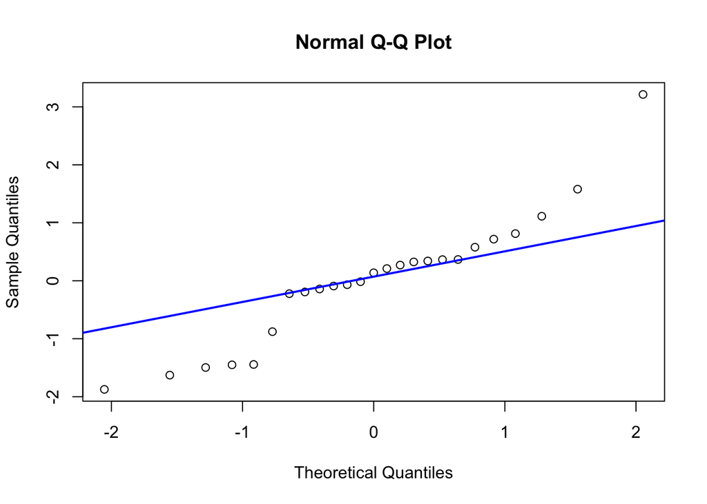

```r
# Gráfico qqnorm
qqnorm(res_3)
qqline(res_3, col = "blue", lwd = 2)
```

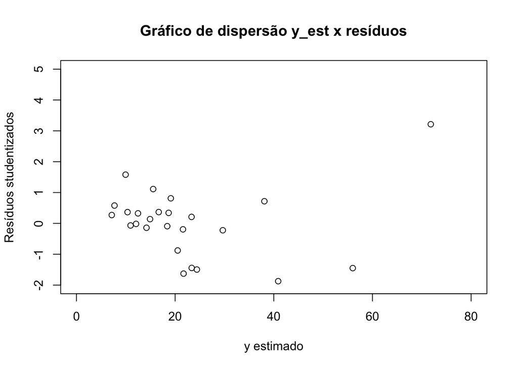

```r
# Gráfico de dispersão y_est x resíduos
y_est <- fitted(mod)
plot(y_est, res_3, xlim = c(0,80), ylim = c(-2,5),
     main = "Gráfico de dispersão y_est x resíduos",
     xlab = "y estimado",
     ylab = "Resíduos studentizados")
```

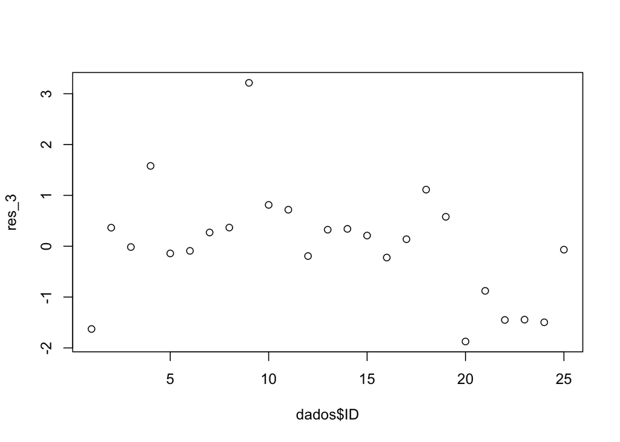

```r
# Gráfico dos resíduos seguindo a ordem de coleta
# ou execução dos dados
# atenção: supondo que a coleta tenha sido na ordem da variável ID, o que nem sempre é verdade!
plot(res_3 ~ dados$ID)
```

## Testes para os resíduos

### Normalidade dos resíduos

Alguns testes são: Qui-quadrado, **Kolmogorov-Smirnov**, Jarque-Bera, **Shapiro-Wilk**, Anderson-Darling, Cramér-von Mises, D’Agostino-Pearson, Lilliefors, e Shapiro-Francia.

```r
# Teste de Shapiro-Wilk
shapiro.test(res_3)
```

```
    Shapiro-Wilk normality test

data:  res_3
W = 0.92285, p-value = 0.05952
```

```r
# Teste de Kolmogorov-Smirnov
ks.test(res_3, "pnorm", mean = 0, sd = 1)
```

```
    Exact one-sample Kolmogorov-Smirnov test

data:  res_3
D = 0.17188, p-value = 0.4052
alternative hypothesis: two-sided
```

### Independência dos Resíduos

Alguns testes são: **Durbin-Watson**, Breusch-Godfrey e Ljung-Box.

Para testar a independência dos resíduos é necessário conhecer a ordem de coleta (ou execução) dos dados.

Supondo que a coleta dos dados tenha sido conforme a variável $ID$ (no exemplo delivery time), então, o teste DW é:

```r
library(lmtest)
dwtest(res_3 ~ dados$ID, alternative = "two.sided")
```

```
    Durbin-Watson test

data:  res_3 ~ dados$ID
DW = 1.3994, p-value = 0.07306
alternative hypothesis: true autocorrelation is not 0
```

### Homocedasticidade dos Resíduos

Alguns testes são: Bartlett, **Breusch-Pagan**, Levene, Samiuddin, O’Neill e Mathews, Layard, Park, White, Cochran, Hartley e Goldfeld-Quandt.

```r
# Teste de Breusch-Pagan
# library(lmtest)
bptest(mod)
```

```
    studentized Breusch-Pagan test

data:  mod
BP = 11.988, df = 2, p-value = 0.002493
```

## Valores discrepantes ou outliers

```r
# Análise de outliers
cbind(dados, res_3)
```

```
   ID     y x1   x2     y_hat       res_3
1   1 16.68  7  560 21.708084 -1.62767993
2   2 11.50  3  220 10.353615  0.36484267
3   3 12.03  3  340 12.079794 -0.01609165
4   4 14.88  4   80  9.955646  1.57972040
5   5 13.75  6  150 14.194398 -0.14176094
6   6 18.11  7  330 18.399574 -0.09080847
7   7  8.00  2  110  7.155376  0.27042496
8   8 17.83  7  210 16.673395  0.36672118
9   9 79.24 30 1460 71.820294  3.21376278
10 10 21.50  5  605 19.123587  0.81325432
11 11 40.33 16  688 38.092507  0.71807970
12 12 21.00 10  215 21.593041 -0.19325733
13 13 13.50  4  255 12.472991  0.32517935
14 14 19.75  6  462 18.682464  0.34113547
15 15 24.00  9  448 23.328798  0.21029137
16 16 29.00 10  776 29.662928 -0.22270023
17 17 15.35  6  200 14.913640  0.13803929
18 18 19.00  7  132 15.551379  1.11295196
19 19  9.50  3   36  7.706807  0.57876634
20 20 35.10 17  770 40.887970 -1.87354643
21 21 17.90 10  140 20.514179 -0.87784258
22 22 52.32 26  810 56.006528 -1.44999541
23 23 18.75  9  450 23.357568 -1.44368977
24 24 19.83  8  635 24.402854 -1.49605875
25 25 10.75  4  150 10.962584 -0.06750861
```

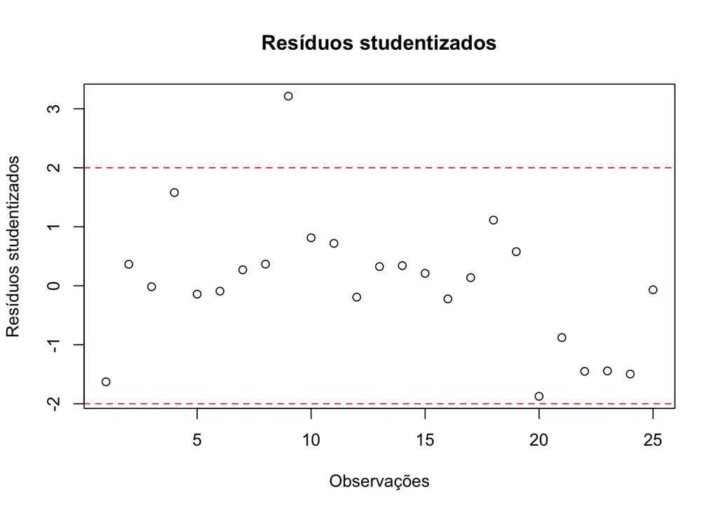

```r
# é necessário verificar se a observação 9 é um outlier.


# gráfico dos resíduos
plot(res_3, main = "Resíduos studentizados",
     ylab = "Resíduos studentizados",
     xlab = "Observações")
abline(h = 2, col = "red", lty = 2)
abline(h = -2, col = "red", lty = 2)
```

```r
# Se for, de fato, um outlier, o que fazer?
# Estimar novamente o modelo sem a observação 9.

mod_2 <- lm(y ~ x1 + x2, data = dados[-9,])
summary(mod_2)
```

```
Call:
lm(formula = y ~ x1 + x2, data = dados[-9, ])

Residuals:
    Min      1Q  Median      3Q     Max
-4.0325 -1.2331  0.0199  1.4730  4.8167

Coefficients:
            Estimate Std. Error t value Pr(>|t|)
(Intercept) 4.447238   0.952469   4.669 0.000131 ***
x1          1.497691   0.130207  11.502 1.58e-10 ***
x2          0.010324   0.002854   3.618 0.001614 **
---
Signif. codes:  0 '***' 0.001 '**' 0.01 '*' 0.05 '.' 0.1 ' ' 1

Residual standard error: 2.43 on 21 degrees of freedom
Multiple R-squared:  0.9487,    Adjusted R-squared:  0.9438
F-statistic: 194.2 on 2 and 21 DF,  p-value: 2.859e-14
```

```r
# comparar os resultados dos dois modelos:
summary(mod)
```

```
Call:
lm(formula = y ~ x1 + x2, data = dados)

Residuals:
    Min      1Q  Median      3Q     Max
-5.7880 -0.6629  0.4364  1.1566  7.4197

Coefficients:
            Estimate Std. Error t value Pr(>|t|)
(Intercept) 2.341231   1.096730   2.135 0.044170 *
x1          1.615907   0.170735   9.464 3.25e-09 ***
x2          0.014385   0.003613   3.981 0.000631 ***
---
Signif. codes:  0 '***' 0.001 '**' 0.01 '*' 0.05 '.' 0.1 ' ' 1

Residual standard error: 3.259 on 22 degrees of freedom
Multiple R-squared:  0.9596,    Adjusted R-squared:  0.9559
F-statistic: 261.2 on 2 and 22 DF,  p-value: 4.687e-16
```

```r
summary(mod_2)
```

```
Call:
lm(formula = y ~ x1 + x2, data = dados[-9, ])

Residuals:
    Min      1Q  Median      3Q     Max
-4.0325 -1.2331  0.0199  1.4730  4.8167

Coefficients:
            Estimate Std. Error t value Pr(>|t|)
(Intercept) 4.447238   0.952469   4.669 0.000131 ***
x1          1.497691   0.130207  11.502 1.58e-10 ***
x2          0.010324   0.002854   3.618 0.001614 **
---
Signif. codes:  0 '***' 0.001 '**' 0.01 '*' 0.05 '.' 0.1 ' ' 1

Residual standard error: 2.43 on 21 degrees of freedom
Multiple R-squared:  0.9487,    Adjusted R-squared:  0.9438
F-statistic: 194.2 on 2 and 21 DF,  p-value: 2.859e-14
```

```r
# Estatística PRESS
PRESS_mod <- sum(res_4^2)
PRESS_mod
```

```
[1] 459.0393
```

```r
res_4_mod_2 <- rstandard(mod_2, type = "pred")
PRESS_mod_2 <- sum(res_4_mod_2^2)
PRESS_mod_2
```

```
[1] 165.2484
```

```r
# Comparar as estatísticas PRESS
PRESS_mod
```

```
[1] 459.0393
```

```r
PRESS_mod_2
```

```
[1] 165.2484
```

## Pontos de alavancagem (leverage points)

Ponto de alavancagem é uma observação que tem valores incomuns nas variáveis preditoras $x_i$, $i=1,\cdots,k$, ou seja, é um ponto que está “longe” do centro de massa das demais observações no espaço das preditoras. Já um ponto influente é uma observação que, se removida do conjunto de dados, provoca uma mudança substancial nos resultados da análise (coeficientes estimados, valores preditos, erros padrão ou estatísticas de ajuste como $R^2$).

O valor de alavancagem $\hat{h}_{ii}$ é o $i$-ésimo elemento da diagonal da matriz chapéu (hat matrix) $H = X(X^TX)^{-1}X^T$. O valor de alavancagem é uma medida de quão longe a observação $x_i$ está do centro das preditoras. O valor de alavancagem varia entre 0 e 1, e a média dos valores de alavancagem é dada por $\bar{h} = \frac{p+1}{n}$, onde $p$ é o número de preditores e $n$ é o número de observações. Valores de alavancagem maiores que $\frac{2p}{n}$ são merecem atenção.

```r
# valores matriz H
p <- 3 # qde de parâmetros (b0, b1 e b2)
#ou
p <- length(coef(mod))


n <- 25 # qde de observaçoes
# ou
n <- length(dados$y)

2*p/n  # limite para valores da matriz hat
```

```
[1] 0.24
```

```r
h <- hatvalues(mod)
cbind(dados, h, 2*p/n, h > 2*p/n)
```

```
   ID     y x1   x2     y_hat          h 2 * p/n h > 2 * p/n
1   1 16.68  7  560 21.708084 0.10180178    0.24       FALSE
2   2 11.50  3  220 10.353615 0.07070164    0.24       FALSE
3   3 12.03  3  340 12.079794 0.09873476    0.24       FALSE
4   4 14.88  4   80  9.955646 0.08537479    0.24       FALSE
5   5 13.75  6  150 14.194398 0.07501050    0.24       FALSE
6   6 18.11  7  330 18.399574 0.04286693    0.24       FALSE
7   7  8.00  2  110  7.155376 0.08179867    0.24       FALSE
8   8 17.83  7  210 16.673395 0.06372559    0.24       FALSE
9   9 79.24 30 1460 71.820294 0.49829216    0.24        TRUE
10 10 21.50  5  605 19.123587 0.19629595    0.24       FALSE
11 11 40.33 16  688 38.092507 0.08613260    0.24       FALSE
12 12 21.00 10  215 21.593041 0.11365570    0.24       FALSE
13 13 13.50  4  255 12.472991 0.06112463    0.24       FALSE
14 14 19.75  6  462 18.682464 0.07824332    0.24       FALSE
15 15 24.00  9  448 23.328798 0.04111077    0.24       FALSE
16 16 29.00 10  776 29.662928 0.16594043    0.24       FALSE
17 17 15.35  6  200 14.913640 0.05943202    0.24       FALSE
18 18 19.00  7  132 15.551379 0.09626046    0.24       FALSE
19 19  9.50  3   36  7.706807 0.09644857    0.24       FALSE
20 20 35.10 17  770 40.887970 0.10168486    0.24       FALSE
21 21 17.90 10  140 20.514179 0.16527689    0.24       FALSE
22 22 52.32 26  810 56.006528 0.39157522    0.24        TRUE
23 23 18.75  9  450 23.357568 0.04126005    0.24       FALSE
24 24 19.83  8  635 24.402854 0.12060826    0.24       FALSE
25 25 10.75  4  150 10.962584 0.06664345    0.24       FALSE
```

```r
# observações 9 e 22 são possíveis pontos de alavancagem.
```

## Distância de Cook

A distância de Cook é uma medida que combina a alavancagem e o resíduo para avaliar a influência de cada observação no ajuste do modelo. Ela é calculada como:
$$D_i = \frac{(\hat{\boldsymbol{\beta}} - \hat{\boldsymbol{\beta}}_{(-i)})^T (X^TX) (\hat{\boldsymbol{\beta}} - \hat{\boldsymbol{\beta}}_{(-i)})}{(p+1)\hat{\sigma}^2}.$$

```r
# Distância de Cook
D <- cooks.distance(mod)

# comparar com o valor 1
# Se D > 1, a observação é considerada um ponto influente.

cbind(dados, D, 1, D > 1)
```

```
   ID     y x1   x2     y_hat            D 1 D > 1
1   1 16.68  7  560 21.708084 1.000921e-01 1 FALSE
2   2 11.50  3  220 10.353615 3.375704e-03 1 FALSE
3   3 12.03  3  340 12.079794 9.455785e-06 1 FALSE
4   4 14.88  4   80  9.955646 7.764718e-02 1 FALSE
5   5 13.75  6  150 14.194398 5.432217e-04 1 FALSE
6   6 18.11  7  330 18.399574 1.231067e-04 1 FALSE
7   7  8.00  2  110  7.155376 2.171604e-03 1 FALSE
8   8 17.83  7  210 16.673395 3.051135e-03 1 FALSE
9   9 79.24 30 1460 71.820294 3.419318e+00 1  TRUE
10 10 21.50  5  605 19.123587 5.384516e-02 1 FALSE
11 11 40.33 16  688 38.092507 1.619975e-02 1 FALSE
12 12 21.00 10  215 21.593041 1.596392e-03 1 FALSE
13 13 13.50  4  255 12.472991 2.294737e-03 1 FALSE
14 14 19.75  6  462 18.682464 3.292786e-03 1 FALSE
15 15 24.00  9  448 23.328798 6.319880e-04 1 FALSE
16 16 29.00 10  776 29.662928 3.289086e-03 1 FALSE
17 17 15.35  6  200 14.913640 4.013419e-04 1 FALSE
18 18 19.00  7  132 15.551379 4.397807e-02 1 FALSE
19 19  9.50  3   36  7.706807 1.191868e-02 1 FALSE
20 20 35.10 17  770 40.887970 1.324449e-01 1 FALSE
21 21 17.90 10  140 20.514179 5.086063e-02 1 FALSE
22 22 52.32 26  810 56.006528 4.510455e-01 1 FALSE
23 23 18.75  9  450 23.357568 2.989892e-02 1 FALSE
24 24 19.83  8  635 24.402854 1.023224e-01 1 FALSE
25 25 10.75  4  150 10.962584 1.084694e-04 1 FALSE
```

## DFBETAS

A medida DFBETAS (do inglês **Difference in Betas**) avalia a influência de cada observação em cada coeficiente estimado. Ela é calculada como:
$$\text{DFBETAS}_{ij} = \frac{\hat{\beta}_j - \hat{\beta}_{j(-i)}}{\hat{\sigma}_{(-i)} \sqrt{(X^TX)^{-1}_{jj}}},$$
em que $\hat{\beta}_j$ é o coeficiente estimado para o preditor $j$ usando todos os dados, $\hat{\beta}_{j(-i)}$ é o coeficiente estimado para o preditor $j$ quando a observação $i$ é removida, e $\hat{\sigma}_{(-i)}$ é a estimativa do desvio padrão dos resíduos quando a observação $i$ é removida. Valores absolutos de DFBETAS maiores que $2/\sqrt{n}$ indicam que a observação tem uma influência significativa no coeficiente estimado.

```r
# DFBETAS
# a influência de cada observação em cada coeficiente
# comparar com o valor 2/sqrt(n)

dfbetas(mod)
```

```
    (Intercept)            x1           x2
1  -0.187267279  0.4113118750 -0.434862094
2   0.089793299 -0.0477642427  0.014414155
3  -0.003515177  0.0039483525 -0.002846468
4   0.451964743  0.0882802920 -0.273373097
5  -0.031674102 -0.0133001129  0.024240457
6  -0.014681480  0.0017921068  0.001078986
7   0.078071285 -0.0222783194 -0.011018802
8   0.071202807  0.0333823324 -0.053823961
9  -2.575739806  0.9287433421  1.507550618
10  0.107919369 -0.3381628707  0.341326746
11 -0.034274535  0.0925271540 -0.002686252
12 -0.030268935 -0.0486664488  0.053973390
13  0.072366473 -0.0356212226  0.011335105
14  0.049516699 -0.0670868604  0.061816778
15  0.022279094 -0.0047895025  0.006838236
16 -0.002693186  0.0644208340 -0.084187552
17  0.028855555  0.0064876499 -0.015696507
18  0.248558020  0.1897331043 -0.272430555
19  0.172558506  0.0235737344 -0.098968842
20  0.168036548 -0.2149950233 -0.092915080
21 -0.161928685 -0.2971750929  0.336406248
22  0.398566309 -1.0254140704  0.573140240
23 -0.159852248  0.0372930389 -0.052651959
24 -0.119720216  0.4046225960 -0.465446949
25 -0.016816024  0.0008498979  0.005592192
```

```r
2/sqrt(n)
```

```
[1] 0.4
```

```r
round(dfbetas(mod), 2)
```

```
   (Intercept)    x1    x2
1        -0.19  0.41 -0.43
2         0.09 -0.05  0.01
3         0.00  0.00  0.00
4         0.45  0.09 -0.27
5        -0.03 -0.01  0.02
6        -0.01  0.00  0.00
7         0.08 -0.02 -0.01
8         0.07  0.03 -0.05
9        -2.58  0.93  1.51
10        0.11 -0.34  0.34
11       -0.03  0.09  0.00
12       -0.03 -0.05  0.05
13        0.07 -0.04  0.01
14        0.05 -0.07  0.06
15        0.02  0.00  0.01
16        0.00  0.06 -0.08
17        0.03  0.01 -0.02
18        0.25  0.19 -0.27
19        0.17  0.02 -0.10
20        0.17 -0.21 -0.09
21       -0.16 -0.30  0.34
22        0.40 -1.03  0.57
23       -0.16  0.04 -0.05
24       -0.12  0.40 -0.47
25       -0.02  0.00  0.01
```

```r
abs(dfbetas(mod)) >= 2/sqrt(n)
```

```
   (Intercept)    x1    x2
1        FALSE  TRUE  TRUE
2        FALSE FALSE FALSE
3        FALSE FALSE FALSE
4         TRUE FALSE FALSE
5        FALSE FALSE FALSE
6        FALSE FALSE FALSE
7        FALSE FALSE FALSE
8        FALSE FALSE FALSE
9         TRUE  TRUE  TRUE
10       FALSE FALSE FALSE
11       FALSE FALSE FALSE
12       FALSE FALSE FALSE
13       FALSE FALSE FALSE
14       FALSE FALSE FALSE
15       FALSE FALSE FALSE
16       FALSE FALSE FALSE
17       FALSE FALSE FALSE
18       FALSE FALSE FALSE
19       FALSE FALSE FALSE
20       FALSE FALSE FALSE
21       FALSE FALSE FALSE
22       FALSE  TRUE  TRUE
23       FALSE FALSE FALSE
24       FALSE  TRUE  TRUE
25       FALSE FALSE FALSE
```

## DFFITS

A medida DFFITS (do inglês **Difference in Fits**) avalia a influência de cada observação em cada predição. Ela é calculada como:
$$\text{DFFITS}_i = \frac{\hat{Y}_i - \hat{Y}_{i(-i)}}{\hat{\sigma}_{(-i)} \sqrt{\hat{h}_{ii}}},$$
em que $\hat{Y}_i$ é o valor predito para a observação $i$ usando todos os dados, $\hat{Y}_{i(-i)}$ é o valor predito para a observação $i$ quando a observação $i$ é removida, $\hat{\sigma}_{(-i)}$ é a estimativa do desvio padrão dos resíduos quando a observação $i$ é removida, e $\hat{h}_{ii}$ é o valor de alavancagem para a observação $i$. Valores absolutos de DFFITS maiores que $2\sqrt{p/n}$ indicam que a observação tem uma influência significativa na predição.

```r
# DFFITS
# a influência de cada observação em cada predição
# comparar com o valor 2*sqrt(p/n)

dffits(mod)
```

```
           1            2            3            4            5            6
-0.570850478  0.098618619 -0.005203676  0.500801817 -0.039458989 -0.018779374
           7            8            9           10           11           12
 0.078990030  0.093760764  4.296080927  0.398713071  0.217953207 -0.067670223
          13           14           15           16           17           18
 0.081259033  0.097362643  0.042584374 -0.097159801  0.033915978  0.365309285
          19           20           21           22           23           24
 0.186167873 -0.671771402 -0.388501185 -1.195036104 -0.307538544 -0.571139627
          25
-0.017626149
```

```r
2*sqrt(p/n)
```

```
[1] 0.6928203
```

```r
round(dffits(mod), 2)
```

```
    1     2     3     4     5     6     7     8     9    10    11    12    13
-0.57  0.10 -0.01  0.50 -0.04 -0.02  0.08  0.09  4.30  0.40  0.22 -0.07  0.08
   14    15    16    17    18    19    20    21    22    23    24    25
 0.10  0.04 -0.10  0.03  0.37  0.19 -0.67 -0.39 -1.20 -0.31 -0.57 -0.02
```

```r
abs(dffits(mod)) >= 2*sqrt(p/n)
```

```
    1     2     3     4     5     6     7     8     9    10    11    12    13
FALSE FALSE FALSE FALSE FALSE FALSE FALSE FALSE  TRUE FALSE FALSE FALSE FALSE
   14    15    16    17    18    19    20    21    22    23    24    25
FALSE FALSE FALSE FALSE FALSE FALSE FALSE FALSE  TRUE FALSE FALSE FALSE
```

[@profjulianobortolini](https://instagram.com/profjulianobortolini) www.julianobortolini.com.br [linkedin](https://linkedin.com/in/julianobortolini) [github](https://github.com/julianobortolini) [lattes](http://lattes.cnpq.br/6210909768845403)